# Chapter 2: Context Free Languages

# Grammars and Context-Free Languages

## Languages and Computation

- Our computational models can input a string and output one bit of information.
- So we can characterize computational models by the languages they recognize.
- Regular languages are the languages recognized by DFA’s, NFA’s, GNFA’s, and described by regular expressions.
- Not all languages are regular (Pumping Lemma).

In Chapter 2, we introduce a more powerful computational model and determine what it can and cannot do.

# Applications to compiler design

## Lexical Analyzers (“lexers”)

Numerical constants can be integers, decimals, possibly with leading 0’s, possibly with +/- signs. When parsing code, it is useful to describe the set of legal numbers as a regular language.

- $D = \{0,1,2,3,4,5,6,7,8,9\}$
- $\Sigma = D \cup \{+, -, .\}$

Numerical constant:

$$(+ \cup - \cup \varepsilon)(D^+ \cup D^+.D^* \cup D^*.D^+)$$

## Nonregular structures in code

However, not all syntax can be described with regular languages.

```r
if(b1) {
  if(b2) {
    if(b3) {
      dosomething(1)
    } else
      dosomething(2)
  } else
    dosomething(3)
} else
  dosomething(4)
```

Morally, structures like these are the same as $\{0^p1^p \mid p>0\}$, which is nonregular. So a parser can’t be a DFA.

# Application to lingustics

## Word-chain automata

$\Sigma =$ words from a language. Can we describe all sentences?

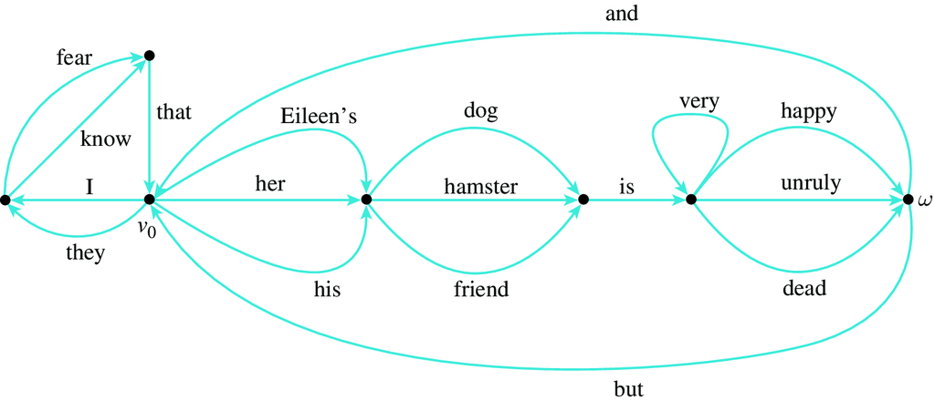

## Long-distance dependencies

> The fact that Bill thinks that if someone needs glasses to read a magazine then that person shouldn’t be allowed to drive makes me want to scream.
- The concluding phrase “makes me want to scream” depends on the opening phrase “The fact that”.
- Long-distance dependencies are essentially nonregular features.
- Noam Chomsky famously observed that human languages have structures that DFA’s can’t recognize (recursion).

# Context-Free Grammars

## Recursively Defined Sets

Define a set of strings $A$ over $\{\mathtt{0}, \mathtt{1}\}$ as follows.

- Base case: $\varepsilon \in A$.
- Recursive case: If $s \in A$, then so is $\mathtt{1}s\mathtt{0}$.

Describe all the elements of $A$.

## Context-Free Grammar

A **context-free grammar** is a 4-tuple $(V, \Sigma, R, S)$, where

1. $V$ is a finite set, called the *variables*,
2. $\Sigma$ is a finite set, disjoint from $V$, called the *terminals*,
3. $R$ is a finite set of *rules*, with each rule of the form $X \rightarrow \mathcal{Q}$, where $X$ is a variable and $\mathcal{Q}$ is a string of variables and terminals.
4. $S \in V$ is the start variable.

The set of all strings of terminals that can be derived from the start symbol $S$ is called the **language of the grammar**. The language of a context-free grammar (CFG) is a **context-free language** (CFL).

## Context-Free Grammar: example

1. $V$ is a finite set, called the *variables*,
2. $\Sigma$ is a finite set, disjoint from $V$, called the *terminals*,
3. $R$ is a finite set of *rules*, with each rule of the form $X \rightarrow \mathcal{Q}$, where $X$ is a variable and $\mathcal{Q}$ is a string of variables and terminals.
4. $S \in V$ is the start variable.

Example: $V = \{S\}$, $\Sigma = \{\mathtt{0}, \mathtt{1}\}$, and the rules $R$ are:

$$\begin{align*}
S & \rightarrow \varepsilon \\
S & \rightarrow \mathtt{0}S\mathtt{1}
\end{align*}$$

Abbreviate this as $S \rightarrow \varepsilon \mid \mathtt{0}S\mathtt{1}$.

## Example: parsing arithmetic

- Variables: $V = \{E, T, F\}$, with $S = E$.
- Terminals: $\{\mathtt{a}, +, \ast, \mathtt{(}, \mathtt{)}\}$.
- Rules:

$$\begin{align*}
E & \rightarrow E + T \mid T \\
T & \rightarrow T \ast F \mid F \\
F & \rightarrow \mathtt{(} E \mathtt{)} \mid \mathtt{a}
\end{align*}$$

Show that $\mathtt{a}+\mathtt{a}*\mathtt{a}$ and $(\mathtt{a}+\mathtt{a})*\mathtt{a}$ are strings in this grammar (give *derivations*).

## Exercise

1. Construct a context-free grammar (CFG) describes the language over $\Sigma=\{\mathtt{0},\mathtt{1}\}$ consisting of all strings with the same number of $\mathtt{0}$’s as $\mathtt{1}$’s.
2. Give derivations for $\mathtt{01}$, $\mathtt{0011}$, and $\mathtt{0110100011}$.